# Lund University BIOS14 Final Exam

## Jacob Daigle | 2025-01-15

For this exam, we are given a large dataset concerning a field monitoring project studying two species of European riverine damselfly, *Calopteryx splendens*, and *Calopteryx virgo*.

The questions I am interested in attempting to explore using this dataset are as follows:

1. Forewing patch length and width (and thus area) are supposedly a target of sexual selection. Is this reflected in this dataset? How does an increase in patch area affect the probability an individual is to have copulated?
2. What is the relationship between body size and wing size, taking into account differences in sexes and species?
3. How have the different body segment lengths changed over time?

```r
rm(list = ls())
library(dplyr)
male_CS <- read.csv("../Data/male_CS.csv")
male_CV <- read.csv("../Data/male_CV.csv")
female_CS <- read.csv("../Data/female_CS.csv")
female_CV <- read.csv("../Data/female_CV.csv")
dat <- bind_rows(male_CS, male_CV, female_CS, female_CV)
dat[["fpa"]] <- dat[["fpl"]] * dat[["fpw"]]

logit = function(x) log(x/(1 - x))
invlogit = function(x) 1/(1 + exp(-x))
```

# Forewing Patch Area and Copulation Status

An increase of one standard deviation of forewing patch area is associated with a *drop* in likelihood to copulate by 0.9%. The coefficient of discrimination calculated to be 0.0022.

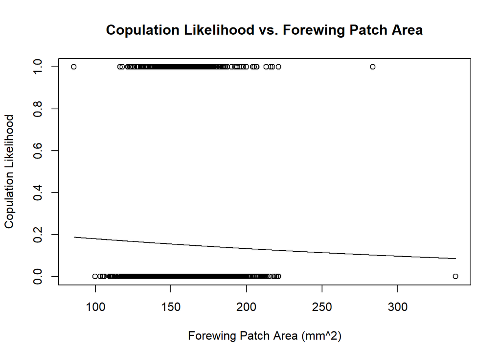

```r
plot(dat$fpa, dat$cop, main = "Copulation Likelihood vs. Forewing Patch Area",
     xlab = "Forewing Patch Area (mm^2)", ylab = "Copulation Likelihood")

# Logistic regression, binary response variable
cop_by_fpa <- glm(formula = cop ~ fpa, family = binomial(link = "logit"), data = dat)
xvals <- seq(min(dat$fpa, na.rm = T), max(dat$fpa, na.rm = T), 0.1)
coefs <- cop_by_fpa$coefficients
yvals <- coefs[1] + coefs[2]*xvals

lines(xvals, invlogit(yvals))
```

```r
# Calculates difference between mean and mean + 1SD
print(
    invlogit(
        coefs[1] + coefs[2] * (mean(dat$fpa, na.rm = T) + sd(dat$fpa, na.rm = T))
    ) - invlogit(
        coefs[1] + coefs[2] * (mean(dat$fpa, na.rm = T))
    )
)
```

```
##  (Intercept)
## -0.009033329
```

```r
# Calculates coefficient of discrimination
print(
    mean(invlogit(yvals)[which(dat$cop == 1)], na.rm = T)
         - mean(invlogit(yvals)[which(dat$cop == 0)], na.rm = T)
    )
```

```
## [1] 0.002163968
```

# Forewing Length and Body Size

The variance in forewing is partitioned as follows:

| Parameter | Amount of Variance Explained |
| --- | --- |
| Total body length | 5.2% |
| Species | 3.9% |
| Sex | 45.5% |
| Interaction of sex and species | 0.7% |
| Residuals (unexplained) | 44.6% |

We expect wing length to relate allometrically to total body length, so $winglength = a\times bodylength^b$. We can take the log of both sides to be able to fit a linear regression to the data, so $\text{log}(winglength) = \text{log}(a) + b\times\text{log}(bodylength)$. An ANCOVA analysis is performed twice to see the difference sex and species each have on the relationship.

As seen in the graph, though, there does appear to be three subgroups of *C. Splendens*. I’m not sure exactly what the subgroups are, but I decided to redo the ANOVA for this species assuming three differently sized subgroups, which I’ve labelled “small”, “medium”, and “large”, though of course all are very close in size.

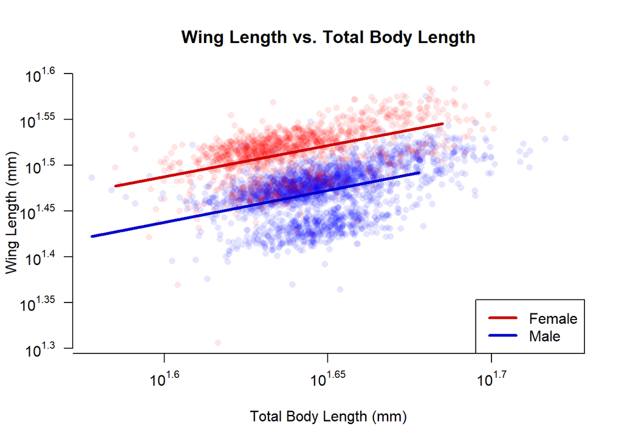

```r
# By Sex ----------------------------------
# Log-log is taken so relationship is linear
fwl_by_tbl_sex <- lm(log10(fwl) ~ log10(tbl) * as.factor(sex), data = dat)
coefs <- summary(fwl_by_tbl_sex)$coef

# X values used to graph regression lines within data later
xvals1 <- seq(
    min(log10(dat$tbl[dat$sex == "Female"]), na.rm = T),
    max(log10(dat$tbl[dat$sex == "Female"]), na.rm = T),
    0.1)
xvals2 <- seq(
    min(log10(dat$tbl[dat$sex == "Male"]), na.rm = T),
    max(log10(dat$tbl[dat$sex == "Male"]), na.rm = T),
    0.1)

plot(log10(dat$tbl), log10(dat$fwl),
     main = "Wing Length vs. Total Body Length",
     xlab = "Total Body Length (mm)", ylab = "Wing Length (mm)",
     pch = 16, cex = 1, axes = F,
     col = c(rgb(1, 0, 0, 0.1), rgb(0, 0, 1, 0.1))[(dat$sex == "Male") + 1])
# Axes are drawn manually to get 10^(log value) instead of (log value)
axis(1, at = seq(1.55, 1.75, 0.05),
     labels = parse(text = paste0("10^", seq(1.55, 1.75, 0.05))))
axis(2, at = seq(1.3, 1.6, 0.05), las = 1,
     labels = parse(text = paste0("10^", seq(1.3, 1.6, 0.05))))

# Regression lines (linear)
lines(xvals1, coefs[1, 1] + coefs[2, 1] * xvals1,
      col = "red3", lwd = 3)
lines(xvals2, coefs[1, 1] + coefs[3, 1] + (coefs[2, 1] + coefs[4, 1]) * xvals2,
      col = "blue3", lwd = 3)

legend("bottomright",
       c("Female", "Male"),
       col = c("red3", "blue3"),
       lwd = 3)
```

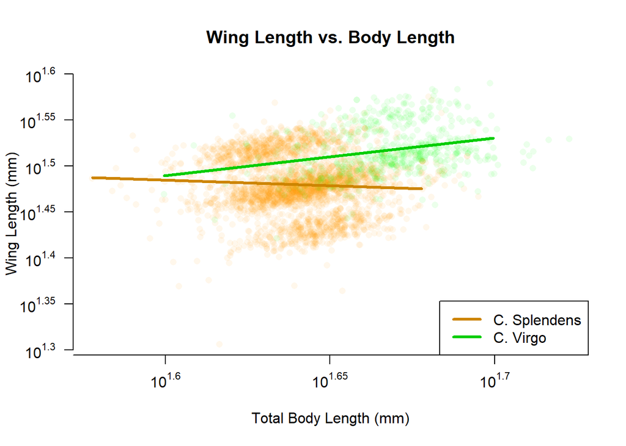

```r
# By Species -------------------------------

fwl_by_tbl <- lm(log10(fwl) ~ log10(tbl) * as.factor(sp), data = dat)
coefs <- summary(fwl_by_tbl)$coef

xvals1 <- seq(
    min(log10(dat$tbl[dat$sp == "CS"]), na.rm = T),
    max(log10(dat$tbl[dat$sp == "CS"]), na.rm = T),
    0.1)
xvals2 <- seq(
    min(log10(dat$tbl[dat$sp == "CV"]), na.rm = T),
    max(log10(dat$tbl[dat$sp == "CV"]), na.rm = T),
    0.1)

plot(log10(dat$tbl), log10(dat$fwl),
     main = "Wing Length vs. Body Length",
     xlab = "Total Body Length (mm)", ylab = "Wing Length (mm)",
     pch = 16, cex = 1, axes = F,
     col = c(rgb(255, 150, 0, 20, maxColorValue = 255),
             rgb(0, 255, 0, 20, maxColorValue = 255)
             )[(dat$sp == "CV") + 1])
axis(1, at = seq(1.55, 1.75, 0.05),
     labels = parse(text = paste0("10^", seq(1.55, 1.75, 0.05))))
axis(2, at = seq(1.3, 1.6, 0.05), las = 1,
     labels = parse(text = paste0("10^", seq(1.3, 1.6, 0.05))))

lines(xvals1, coefs[1, 1] + coefs[2, 1] * xvals1,
      col = "orange3", lwd = 3)
lines(xvals2, coefs[1, 1] + coefs[3, 1] + (coefs[2, 1] + coefs[4, 1]) * xvals2,
      col = "green3", lwd = 3)

legend("bottomright",
       c("C. Splendens", "C. Virgo"),
       col = c("orange3", "green3"),
       lwd = 3)
```

```r
summary(fwl_by_tbl_sex)
```

```
##
## Call:
## lm(formula = log10(fwl) ~ log10(tbl) * as.factor(sex), data = dat)
##
## Residuals:
##       Min        1Q    Median        3Q       Max
## -0.192608 -0.010703  0.006169  0.015538  0.081680
##
## Coefficients:
##                               Estimate Std. Error t value Pr(>|t|)
## (Intercept)                    0.39573    0.05710   6.930 4.96e-12 ***
## log10(tbl)                     0.68238    0.03483  19.593  < 2e-16 ***
## as.factor(sex)Male            -0.07478    0.07361  -1.016    0.310
## log10(tbl):as.factor(sex)Male  0.01559    0.04481   0.348    0.728
## ---
## Signif. codes:  0 '***' 0.001 '**' 0.01 '*' 0.05 '.' 0.1 ' ' 1
##
## Residual standard error: 0.0237 on 3614 degrees of freedom
## Multiple R-squared:  0.5073, Adjusted R-squared:  0.5069
## F-statistic:  1240 on 3 and 3614 DF,  p-value: < 2.2e-16
```

```r
summary(fwl_by_tbl)
```

```
##
## Call:
## lm(formula = log10(fwl) ~ log10(tbl) * as.factor(sp), data = dat)
##
## Residuals:
##       Min        1Q    Median        3Q       Max
## -0.176518 -0.018090 -0.001284  0.021901  0.100325
##
## Coefficients:
##                            Estimate Std. Error t value Pr(>|t|)
## (Intercept)                 1.68109    0.06131  27.421  < 2e-16 ***
## log10(tbl)                 -0.12275    0.03737  -3.285  0.00103 **
## as.factor(sp)CV            -0.84418    0.13694  -6.165 7.85e-10 ***
## log10(tbl):as.factor(sp)CV  0.53078    0.08236   6.445 1.31e-10 ***
## ---
## Signif. codes:  0 '***' 0.001 '**' 0.01 '*' 0.05 '.' 0.1 ' ' 1
##
## Residual standard error: 0.03053 on 3614 degrees of freedom
## Multiple R-squared:  0.1828, Adjusted R-squared:  0.1821
## F-statistic: 269.4 on 3 and 3614 DF,  p-value: < 2.2e-16
```

```r
anova(fwl_by_tbl_sex)
```

```
## Analysis of Variance Table
##
## Response: log10(fwl)
##                             Df  Sum Sq Mean Sq  F value Pr(>F)
## log10(tbl)                   1 0.21567 0.21567  383.808 <2e-16 ***
## as.factor(sex)               1 1.87490 1.87490 3336.642 <2e-16 ***
## log10(tbl):as.factor(sex)    1 0.00007 0.00007    0.121  0.728
## Residuals                 3614 2.03076 0.00056
## ---
## Signif. codes:  0 '***' 0.001 '**' 0.01 '*' 0.05 '.' 0.1 ' ' 1
```

```r
anova(fwl_by_tbl)
```

```
## Analysis of Variance Table
##
## Response: log10(fwl)
##                            Df Sum Sq Mean Sq F value    Pr(>F)
## log10(tbl)                  1 0.2157 0.21567 231.415 < 2.2e-16 ***
## as.factor(sp)               1 0.4990 0.49895 535.386 < 2.2e-16 ***
## log10(tbl):as.factor(sp)    1 0.0387 0.03871  41.537 1.309e-10 ***
## Residuals                3614 3.3681 0.00093
## ---
## Signif. codes:  0 '***' 0.001 '**' 0.01 '*' 0.05 '.' 0.1 ' ' 1
```

If we separate *C. Splendens* into three subgroups, we find that for a 10% increase in body length, there is a 3.9%, 2.3%, and 1.9% increase in body length for “small”, “medium”, and “large” flies respectively. The body length, size category, interaction of body length and size category, and residuals account for 0.3%, 86.0%, 0.1%, and 13.6% of the variance respectively.

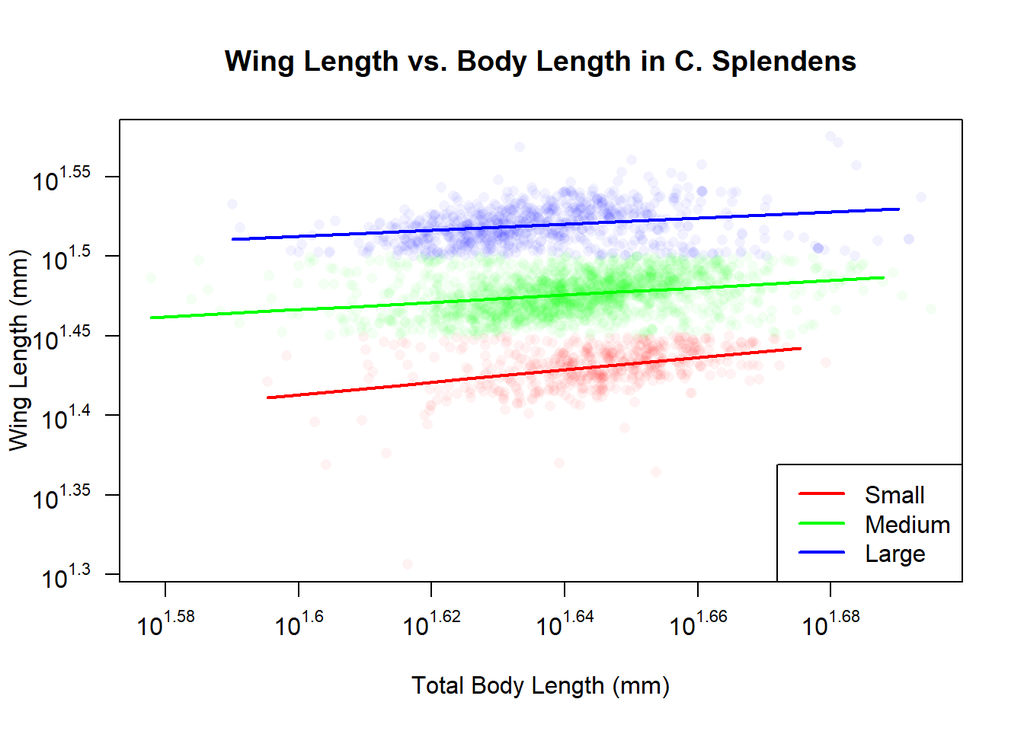

```r
# Subgrouping -------------------------------
subdat <- dat[which(dat$sp == "CS"),]  # Data only of C. Splendens
subdat$size <- factor(cut(
    log10(subdat$fwl),
    c(-Inf, 1.45, 1.5, Inf),
    labels = c("small", "medium", "large")
))

fwl_by_tbl_sub <- lm(log10(fwl) ~ log10(tbl) * size, data = subdat)
coefs <- summary(fwl_by_tbl_sub)$coef

# X values for drawing regression lines within data
xvals1 <- seq(
    min(log10(subdat$tbl[subdat$size == "small"]), na.rm = T),
    max(log10(subdat$tbl[subdat$size == "small"]), na.rm = T),
    0.01)

xvals2 <- seq(
    min(log10(subdat$tbl[subdat$size == "medium"]), na.rm = T),
    max(log10(subdat$tbl[subdat$size == "medium"]), na.rm = T),
    0.01)

xvals3 <- seq(
    min(log10(subdat$tbl[subdat$size == "large"]), na.rm = T),
    max(log10(subdat$tbl[subdat$size == "large"]), na.rm = T),
    0.01)

plot(log10(subdat$tbl), log10(subdat$fwl),
     main = "Wing Length vs. Body Length in C. Splendens",
     xlab = "Total Body Length (mm)", ylab = "Wing Length (mm)",
     pch = 16, cex = 1, axes = F,
     col = c(
         rgb(1, 0, 0, 0.05),
         rgb(0, 1, 0, 0.05),
         rgb(0, 0, 1, 0.05)
     )[subdat$size]
)
box()  # Draws box around the plot

# Axes with 10^(log val) instead of just (log val)
axis(1, at = seq(1.58, 1.7, 0.02),
     labels = parse(text = paste0("10^", seq(1.58, 1.7, 0.02))))
axis(2, at = seq(1.3, 1.6, 0.05), las = 1,
     labels = parse(text = paste0("10^", seq(1.3, 1.6, 0.05))))

# Regression lines
lines(xvals1,
      coefs[1,1] + coefs[2,1] * xvals1,
      col = "red", lwd = 2)  # Small
lines(xvals2,
      coefs[1,1] + coefs[3,1] + (coefs[2,1] + coefs[5,1]) * xvals2,
      col = "green", lwd = 2)  # Medium
lines(xvals3,
      coefs[1,1] + coefs[4,1] + (coefs[2,1] + coefs[6,1]) * xvals3,
      col = "blue", lwd = 2)  # Large

legend("bottomright",
       c("Small", "Medium", "Large"),
       col = c("red", "green", "blue"),
       lwd = 2)
```

```r
summary(fwl_by_tbl_sub)
```

```
##
## Call:
## lm(formula = log10(fwl) ~ log10(tbl) * size, data = subdat)
##
## Residuals:
##       Min        1Q    Median        3Q       Max
## -0.113270 -0.007884 -0.000018  0.007747  0.049871
##
## Coefficients:
##                       Estimate Std. Error t value Pr(>|t|)
## (Intercept)            0.78736    0.06436  12.235  < 2e-16 ***
## log10(tbl)             0.39102    0.03914   9.991  < 2e-16 ***
## sizemedium             0.31160    0.07150   4.358 1.36e-05 ***
## sizelarge              0.41745    0.07837   5.327 1.07e-07 ***
## log10(tbl):sizemedium -0.16127    0.04350  -3.708 0.000213 ***
## log10(tbl):sizelarge  -0.19873    0.04773  -4.163 3.22e-05 ***
## ---
## Signif. codes:  0 '***' 0.001 '**' 0.01 '*' 0.05 '.' 0.1 ' ' 1
##
## Residual standard error: 0.01163 on 3019 degrees of freedom
## Multiple R-squared:  0.8641, Adjusted R-squared:  0.8639
## F-statistic:  3841 on 5 and 3019 DF,  p-value: < 2.2e-16
```

```r
anova(fwl_by_tbl_sub)
```

```
## Analysis of Variance Table
##
## Response: log10(fwl)
##                   Df  Sum Sq Mean Sq   F value    Pr(>F)
## log10(tbl)         1 0.01006 0.01006   74.3868 < 2.2e-16 ***
## size               2 2.58367 1.29183 9555.4721 < 2.2e-16 ***
## log10(tbl):size    2 0.00246 0.00123    9.1115 0.0001135 ***
## Residuals       3019 0.40815 0.00014
## ---
## Signif. codes:  0 '***' 0.001 '**' 0.01 '*' 0.05 '.' 0.1 ' ' 1
```

# Segment Lengths Over Time

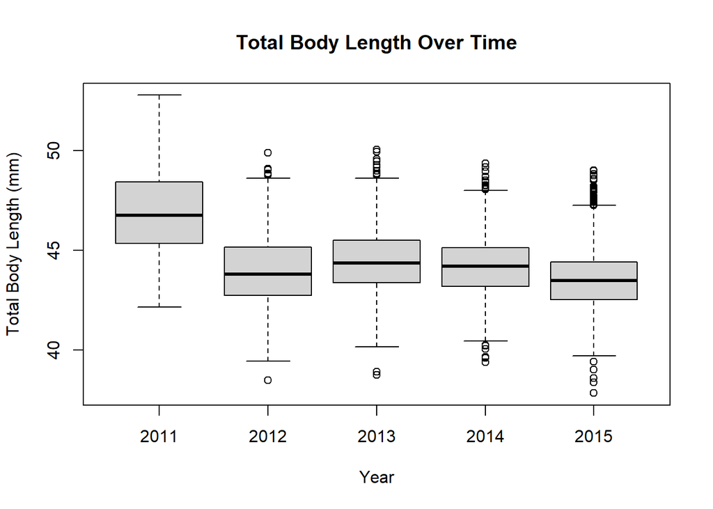

```r
plot(as.factor(dat$year), dat$tbl,
     xlab = "Year", ylab = "Total Body Length (mm)",
     main = "Total Body Length Over Time")
```

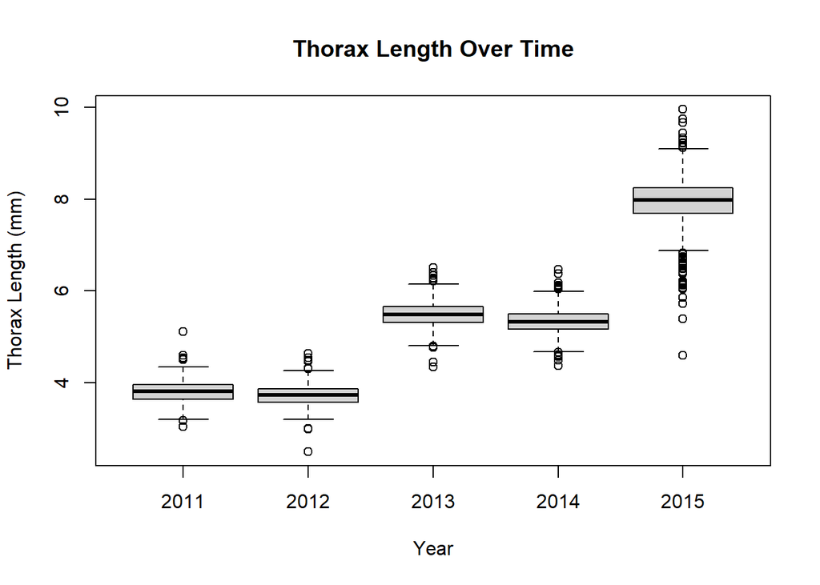

```r
plot(as.factor(dat$year), dat$thorl,
     xlab = "Year", ylab = "Thorax Length (mm)",
     main = "Thorax Length Over Time")
```

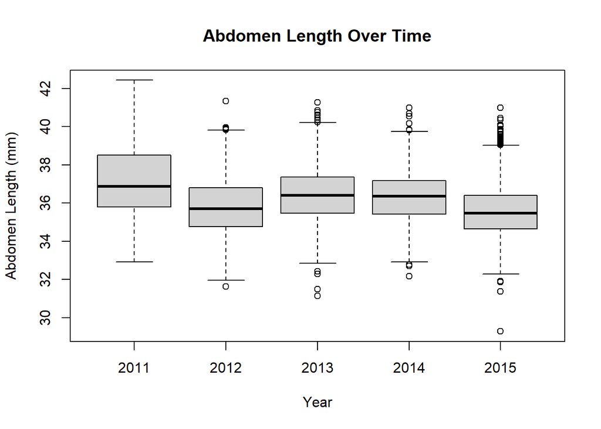

```r
plot(as.factor(dat$year), dat$abl,
     xlab = "Year", ylab = "Abdomen Length (mm)",
     main = "Abdomen Length Over Time")
```

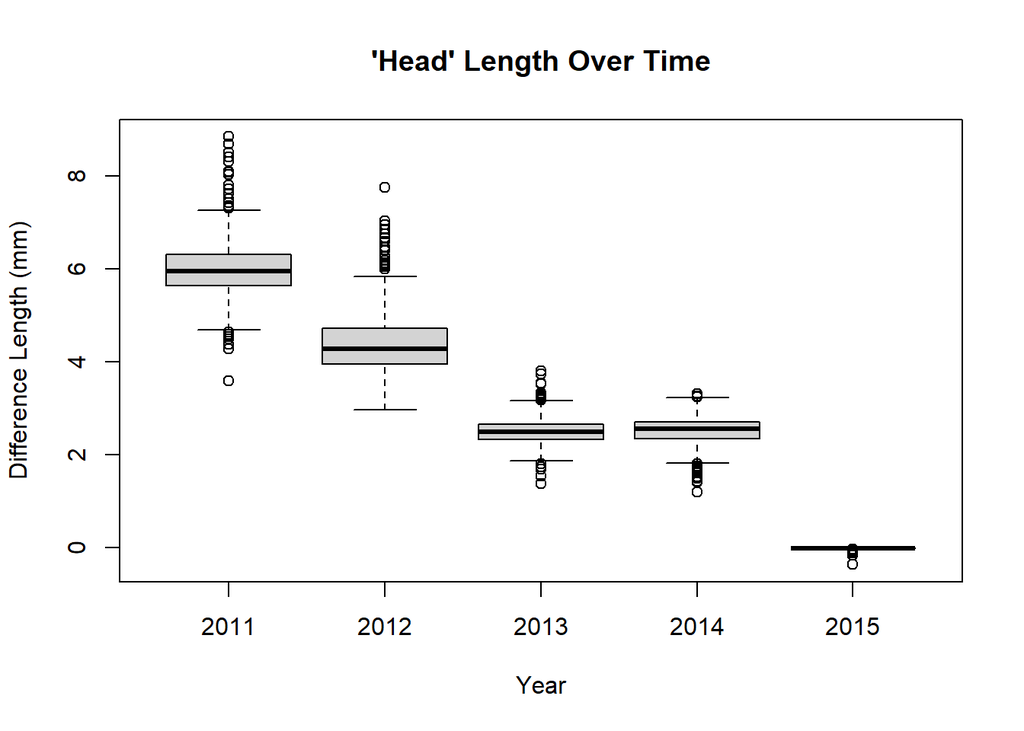

```r
plot(as.factor(dat$year), dat$tbl - (dat$abl + dat$thorl),
     xlab = "Year", ylab = "Difference Length (mm)",
     main = "'Head' Length Over Time")
```

```r
summary(lm(tbl ~ as.numeric(year), data = dat))$coef
```

```
##                     Estimate  Std. Error   t value     Pr(>|t|)
## (Intercept)      976.0270116 47.30269970  20.63364 1.623521e-89
## as.numeric(year)  -0.4627583  0.02349126 -19.69917 3.845732e-82
```

```r
summary(lm(thorl ~ as.numeric(year), data = dat))$coef
```

```
##                      Estimate   Std. Error   t value Pr(>|t|)
## (Intercept)      -2342.597129 18.887064514 -124.0318        0
## as.numeric(year)     1.166319  0.009379613  124.3462        0
```

```r
summary(lm(abl ~ as.numeric(year), data = dat))$coef
```

```
##                     Estimate  Std. Error   t value     Pr(>|t|)
## (Intercept)      495.1526297 40.65245032  12.18014 1.779756e-33
## as.numeric(year)  -0.2279688  0.02018864 -11.29193 4.388975e-29
```

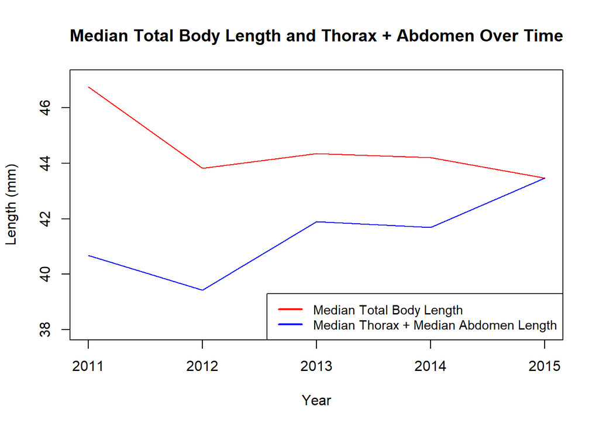

```r
# Calculates the median body, abdomen, and thorax lengths for each year
tbl_med <- tapply(dat$tbl, dat$year, median)
abl_med <- tapply(dat$abl, dat$year, median)
thorl_med <- tapply(dat$thorl, dat$year, median)

# Plots the body lengths along with thorax + abdomen
plot(as.numeric(names(tbl_med)), unname(tbl_med), type = "l",
     ylim = c(38, 47), col = "red",
     xlab = "Year", ylab = "Length (mm)",
     main = "Median Total Body Length and Thorax + Abdomen Over Time")
lines(as.numeric(names(abl_med)), unname(abl_med) + unname(thorl_med),
      col = "blue")
legend("bottomright",
       c("Median Total Body Length",
         "Median Thorax + Median Abdomen Length"),
       col = c("red", "blue"), lwd = 2, cex = 0.9)
```